# 2_class_9_housingdata_exercise1

### Group exercise: housing data

Use the housing dataset and do Exploratory Data Analysis (EDA). Use all the tools you have learned so far (making summaries with groupby, select, filter, statistical summaries, and **especially** plotting.

Try to find patterns; find a story in the data!

As with the Titanic dataset, export your notebook as a pdf or html and upload it to Slack.

```python
import matplotlib.pyplot as plt
import seaborn as sns
import pandas as pd
```

```python
df = pd.read_csv("./data/housing_price.csv")
```

#### Some general info about the dataframe:

```python
df.shape
```

```
(4600, 18)
```

This dataframe (table) has 18 columns and 4600 rows.

```python
df.info()
```

```
<class 'pandas.core.frame.DataFrame'>
RangeIndex: 4600 entries, 0 to 4599
Data columns (total 18 columns):
 #   Column         Non-Null Count  Dtype
---  ------         --------------  -----
 0   date           4600 non-null   object
 1   price          4600 non-null   float64
 2   bedrooms       4600 non-null   float64
 3   bathrooms      4600 non-null   float64
 4   sqft_living    4600 non-null   int64
 5   sqft_lot       4600 non-null   int64
 6   floors         4600 non-null   float64
 7   waterfront     4600 non-null   int64
 8   view           4600 non-null   int64
 9   condition      4600 non-null   int64
 10  sqft_above     4600 non-null   int64
 11  sqft_basement  4600 non-null   int64
 12  yr_built       4600 non-null   int64
 13  yr_renovated   4600 non-null   int64
 14  street         4600 non-null   object
 15  city           4600 non-null   object
 16  statezip       4600 non-null   object
 17  country        4600 non-null   object
dtypes: float64(4), int64(9), object(5)
memory usage: 647.0+ KB
```

All cells have values in them. No Null (NaN) cell is present.

```python
df # the data frame looks like this
```

|  | date | price | bedrooms | bathrooms | sqft_living | sqft_lot | floors | waterfront | view | condition | sqft_above | sqft_basement | yr_built | yr_renovated | street | city | statezip | country |
| --- | --- | --- | --- | --- | --- | --- | --- | --- | --- | --- | --- | --- | --- | --- | --- | --- | --- | --- |
| 0 | 2014-05-02 00:00:00 | 3.130000e+05 | 3.0 | 1.50 | 1340 | 7912 | 1.5 | 0 | 0 | 3 | 1340 | 0 | 1955 | 2005 | 18810 Densmore Ave N | Shoreline | WA 98133 | USA |
| 1 | 2014-05-02 00:00:00 | 2.384000e+06 | 5.0 | 2.50 | 3650 | 9050 | 2.0 | 0 | 4 | 5 | 3370 | 280 | 1921 | 0 | 709 W Blaine St | Seattle | WA 98119 | USA |
| 2 | 2014-05-02 00:00:00 | 3.420000e+05 | 3.0 | 2.00 | 1930 | 11947 | 1.0 | 0 | 0 | 4 | 1930 | 0 | 1966 | 0 | 26206-26214 143rd Ave SE | Kent | WA 98042 | USA |
| 3 | 2014-05-02 00:00:00 | 4.200000e+05 | 3.0 | 2.25 | 2000 | 8030 | 1.0 | 0 | 0 | 4 | 1000 | 1000 | 1963 | 0 | 857 170th Pl NE | Bellevue | WA 98008 | USA |
| 4 | 2014-05-02 00:00:00 | 5.500000e+05 | 4.0 | 2.50 | 1940 | 10500 | 1.0 | 0 | 0 | 4 | 1140 | 800 | 1976 | 1992 | 9105 170th Ave NE | Redmond | WA 98052 | USA |
| ... | ... | ... | ... | ... | ... | ... | ... | ... | ... | ... | ... | ... | ... | ... | ... | ... | ... | ... |
| 4595 | 2014-07-09 00:00:00 | 3.081667e+05 | 3.0 | 1.75 | 1510 | 6360 | 1.0 | 0 | 0 | 4 | 1510 | 0 | 1954 | 1979 | 501 N 143rd St | Seattle | WA 98133 | USA |
| 4596 | 2014-07-09 00:00:00 | 5.343333e+05 | 3.0 | 2.50 | 1460 | 7573 | 2.0 | 0 | 0 | 3 | 1460 | 0 | 1983 | 2009 | 14855 SE 10th Pl | Bellevue | WA 98007 | USA |
| 4597 | 2014-07-09 00:00:00 | 4.169042e+05 | 3.0 | 2.50 | 3010 | 7014 | 2.0 | 0 | 0 | 3 | 3010 | 0 | 2009 | 0 | 759 Ilwaco Pl NE | Renton | WA 98059 | USA |
| 4598 | 2014-07-10 00:00:00 | 2.034000e+05 | 4.0 | 2.00 | 2090 | 6630 | 1.0 | 0 | 0 | 3 | 1070 | 1020 | 1974 | 0 | 5148 S Creston St | Seattle | WA 98178 | USA |
| 4599 | 2014-07-10 00:00:00 | 2.206000e+05 | 3.0 | 2.50 | 1490 | 8102 | 2.0 | 0 | 0 | 4 | 1490 | 0 | 1990 | 0 | 18717 SE 258th St | Covington | WA 98042 | USA |

4600 rows × 18 columns

```python
df.describe() # some characteristics of the data are here: b
```

|  | price | bedrooms | bathrooms | sqft_living | sqft_lot | floors | waterfront | view | condition | sqft_above | sqft_basement | yr_built | yr_renovated |
| --- | --- | --- | --- | --- | --- | --- | --- | --- | --- | --- | --- | --- | --- |
| count | 4.600000e+03 | 4600.000000 | 4600.000000 | 4600.000000 | 4.600000e+03 | 4600.000000 | 4600.000000 | 4600.000000 | 4600.000000 | 4600.000000 | 4600.000000 | 4600.000000 | 4600.000000 |
| mean | 5.519630e+05 | 3.400870 | 2.160815 | 2139.346957 | 1.485252e+04 | 1.512065 | 0.007174 | 0.240652 | 3.451739 | 1827.265435 | 312.081522 | 1970.786304 | 808.608261 |
| std | 5.638347e+05 | 0.908848 | 0.783781 | 963.206916 | 3.588444e+04 | 0.538288 | 0.084404 | 0.778405 | 0.677230 | 862.168977 | 464.137228 | 29.731848 | 979.414536 |
| min | 0.000000e+00 | 0.000000 | 0.000000 | 370.000000 | 6.380000e+02 | 1.000000 | 0.000000 | 0.000000 | 1.000000 | 370.000000 | 0.000000 | 1900.000000 | 0.000000 |
| 25% | 3.228750e+05 | 3.000000 | 1.750000 | 1460.000000 | 5.000750e+03 | 1.000000 | 0.000000 | 0.000000 | 3.000000 | 1190.000000 | 0.000000 | 1951.000000 | 0.000000 |
| 50% | 4.609435e+05 | 3.000000 | 2.250000 | 1980.000000 | 7.683000e+03 | 1.500000 | 0.000000 | 0.000000 | 3.000000 | 1590.000000 | 0.000000 | 1976.000000 | 0.000000 |
| 75% | 6.549625e+05 | 4.000000 | 2.500000 | 2620.000000 | 1.100125e+04 | 2.000000 | 0.000000 | 0.000000 | 4.000000 | 2300.000000 | 610.000000 | 1997.000000 | 1999.000000 |
| max | 2.659000e+07 | 9.000000 | 8.000000 | 13540.000000 | 1.074218e+06 | 3.500000 | 1.000000 | 4.000000 | 5.000000 | 9410.000000 | 4820.000000 | 2014.000000 | 2014.000000 |

```python
df.price.mean()
```

```
551962.9884732141
```

There is a very high difference between mean (552K USD) and median (460K USD), which is due to some very high priced houses. MEAN: ~552K USD MEDIAN: ~460K USD

#### Generating a new data frame with a price cut off of 800K USD

To generate a new dataframe with houses less than 800K will provide a different picture

```python
df['price'].between(0, 800000) # selects houses with price between 0 - 500K and returns True for this condition
# df['price'] <= 800000 gives the same result as code above.
# df.drop.Price > 800000 or df.drop['price'] > 800000 to drop houses with more than 500K do not work.
```

```
0        True
1       False
2        True
3        True
4        True
        ...
4595     True
4596     True
4597     True
4598     True
4599     True
Name: price, Length: 4600, dtype: bool
```

```python
df1 = df[df.price <= 800000] # this dataframe include only houses with <=500K USD
df1
```

|  | date | price | bedrooms | bathrooms | sqft_living | sqft_lot | floors | waterfront | view | condition | sqft_above | sqft_basement | yr_built | yr_renovated | street | city | statezip | country |
| --- | --- | --- | --- | --- | --- | --- | --- | --- | --- | --- | --- | --- | --- | --- | --- | --- | --- | --- |
| 0 | 2014-05-02 00:00:00 | 313000.000000 | 3.0 | 1.50 | 1340 | 7912 | 1.5 | 0 | 0 | 3 | 1340 | 0 | 1955 | 2005 | 18810 Densmore Ave N | Shoreline | WA 98133 | USA |
| 2 | 2014-05-02 00:00:00 | 342000.000000 | 3.0 | 2.00 | 1930 | 11947 | 1.0 | 0 | 0 | 4 | 1930 | 0 | 1966 | 0 | 26206-26214 143rd Ave SE | Kent | WA 98042 | USA |
| 3 | 2014-05-02 00:00:00 | 420000.000000 | 3.0 | 2.25 | 2000 | 8030 | 1.0 | 0 | 0 | 4 | 1000 | 1000 | 1963 | 0 | 857 170th Pl NE | Bellevue | WA 98008 | USA |
| 4 | 2014-05-02 00:00:00 | 550000.000000 | 4.0 | 2.50 | 1940 | 10500 | 1.0 | 0 | 0 | 4 | 1140 | 800 | 1976 | 1992 | 9105 170th Ave NE | Redmond | WA 98052 | USA |
| 5 | 2014-05-02 00:00:00 | 490000.000000 | 2.0 | 1.00 | 880 | 6380 | 1.0 | 0 | 0 | 3 | 880 | 0 | 1938 | 1994 | 522 NE 88th St | Seattle | WA 98115 | USA |
| ... | ... | ... | ... | ... | ... | ... | ... | ... | ... | ... | ... | ... | ... | ... | ... | ... | ... | ... |
| 4595 | 2014-07-09 00:00:00 | 308166.666667 | 3.0 | 1.75 | 1510 | 6360 | 1.0 | 0 | 0 | 4 | 1510 | 0 | 1954 | 1979 | 501 N 143rd St | Seattle | WA 98133 | USA |
| 4596 | 2014-07-09 00:00:00 | 534333.333333 | 3.0 | 2.50 | 1460 | 7573 | 2.0 | 0 | 0 | 3 | 1460 | 0 | 1983 | 2009 | 14855 SE 10th Pl | Bellevue | WA 98007 | USA |
| 4597 | 2014-07-09 00:00:00 | 416904.166667 | 3.0 | 2.50 | 3010 | 7014 | 2.0 | 0 | 0 | 3 | 3010 | 0 | 2009 | 0 | 759 Ilwaco Pl NE | Renton | WA 98059 | USA |
| 4598 | 2014-07-10 00:00:00 | 203400.000000 | 4.0 | 2.00 | 2090 | 6630 | 1.0 | 0 | 0 | 3 | 1070 | 1020 | 1974 | 0 | 5148 S Creston St | Seattle | WA 98178 | USA |
| 4599 | 2014-07-10 00:00:00 | 220600.000000 | 3.0 | 2.50 | 1490 | 8102 | 2.0 | 0 | 0 | 4 | 1490 | 0 | 1990 | 0 | 18717 SE 258th St | Covington | WA 98042 | USA |

3940 rows × 18 columns

```python
df1.info()
```

```
<class 'pandas.core.frame.DataFrame'>
Int64Index: 3940 entries, 0 to 4599
Data columns (total 18 columns):
 #   Column         Non-Null Count  Dtype
---  ------         --------------  -----
 0   date           3940 non-null   object
 1   price          3940 non-null   float64
 2   bedrooms       3940 non-null   float64
 3   bathrooms      3940 non-null   float64
 4   sqft_living    3940 non-null   int64
 5   sqft_lot       3940 non-null   int64
 6   floors         3940 non-null   float64
 7   waterfront     3940 non-null   int64
 8   view           3940 non-null   int64
 9   condition      3940 non-null   int64
 10  sqft_above     3940 non-null   int64
 11  sqft_basement  3940 non-null   int64
 12  yr_built       3940 non-null   int64
 13  yr_renovated   3940 non-null   int64
 14  street         3940 non-null   object
 15  city           3940 non-null   object
 16  statezip       3940 non-null   object
 17  country        3940 non-null   object
dtypes: float64(4), int64(9), object(5)
memory usage: 584.8+ KB
```

```python
df_highPriced = df[df.price > 800000] # this dataframe include only houses with > 800K USD
```

```python
df_highPriced.info()
```

```
<class 'pandas.core.frame.DataFrame'>
Int64Index: 660 entries, 1 to 4572
Data columns (total 18 columns):
 #   Column         Non-Null Count  Dtype
---  ------         --------------  -----
 0   date           660 non-null    object
 1   price          660 non-null    float64
 2   bedrooms       660 non-null    float64
 3   bathrooms      660 non-null    float64
 4   sqft_living    660 non-null    int64
 5   sqft_lot       660 non-null    int64
 6   floors         660 non-null    float64
 7   waterfront     660 non-null    int64
 8   view           660 non-null    int64
 9   condition      660 non-null    int64
 10  sqft_above     660 non-null    int64
 11  sqft_basement  660 non-null    int64
 12  yr_built       660 non-null    int64
 13  yr_renovated   660 non-null    int64
 14  street         660 non-null    object
 15  city           660 non-null    object
 16  statezip       660 non-null    object
 17  country        660 non-null    object
dtypes: float64(4), int64(9), object(5)
memory usage: 98.0+ KB
```

```python
print(660 + 3940)
```

```
4600
```

660 houses among 4600 are priced more than 800K USD and the rest (3940 houses) are priced less than 800K USD

```python
print(df.price.median())
```

```
460943.46153850004
```

```python
int(df.price.median()) # convers the median to integer
```

```
460943
```

```python
int(df1.price.median())
```

```
423025
```

```python
int(df.price.mean())
```

```
551962
```

```python
int(df1.price.mean())
```

```
434043
```

There are 4600 listed houses in dataframe and all are in the US

#### Some graphical analysis

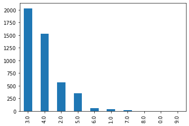

```python
df.bedrooms.value_counts().plot.bar() # the number of houses per the number of bedrooms, graphed in a bar graph
```

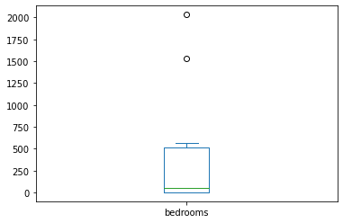

```python
df.bedrooms.value_counts().plot.box() # the number of houses with aggregated number of bedrooms, graphed in a box graph
```

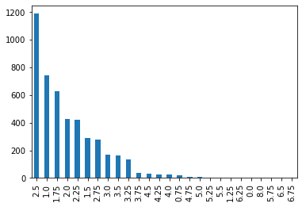

```python
df.bathrooms.value_counts().plot.bar() # the number of houses with aggregated number of bathrooms, graphed in a bar graph
```

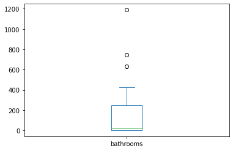

```python
df.bathrooms.value_counts().plot.box() # the number of houses with aggregated number of bathrooms, graphed in a box graph
```

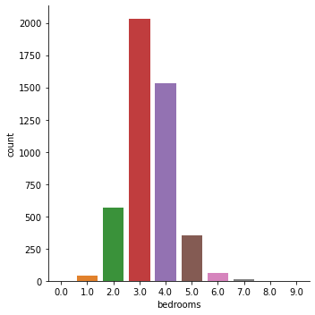

```python
sns.catplot(x ="bedrooms", kind = "count", data = df)
# sns.catplot(x ="bedrooms", hue ="floors", kind =price.mean, data = df)
```

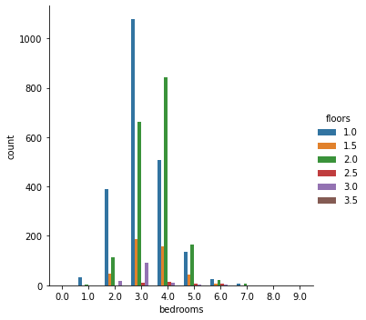

```python
sns.catplot(x ="bedrooms", hue ="floors", kind = "count", data = df)
# sns.catplot(x ="bedrooms", hue ="floors", kind =price.mean, data = df)
```

Most common houses have 3 bedrooms (>2000) followed by 4 bedrooms (1500) and most of the 3 floor houses have 1 floor (about 1100) while most of the 4 bedroom houses have 2 floors (about 850).

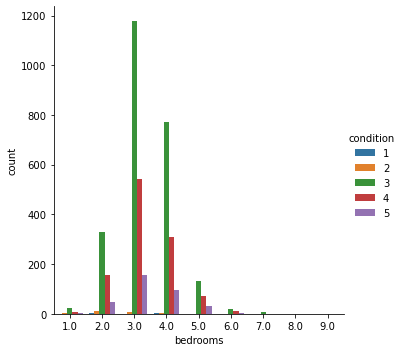

```python
sns.catplot(x ="bedrooms", hue ="condition", kind = 'count', data = df1) # not sure what the numbers for conditions indicate. Uncle Google says 'proximaty to various conditions.
```

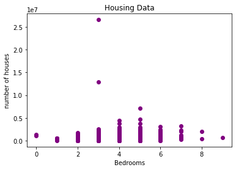

```python
plt.scatter(df.bedrooms, df.price, color='purple') # scatter plot
plt.xlabel("Bedrooms")
plt.ylabel("number of houses")
plt.title("Housing Data")
```

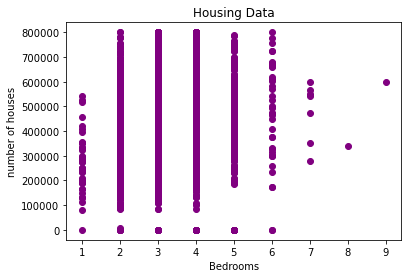

```python
plt.scatter(df1.bedrooms, df1.price, color='purple') # scatter plot
plt.xlabel("Bedrooms")
plt.ylabel("number of houses")
plt.title("Housing Data")
```

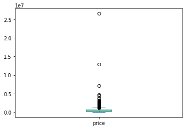

```python
df["price"].plot.box()
```

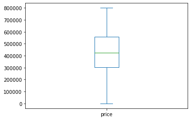

```python
df1["price"].plot.box()
```

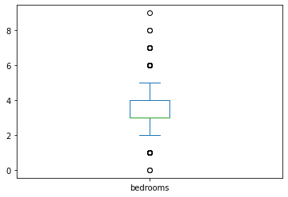

```python
df["bedrooms"].plot.box()
```

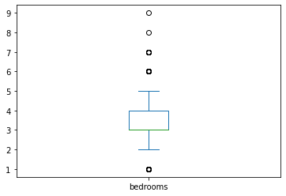

```python
df1["bedrooms"].plot.box()
```

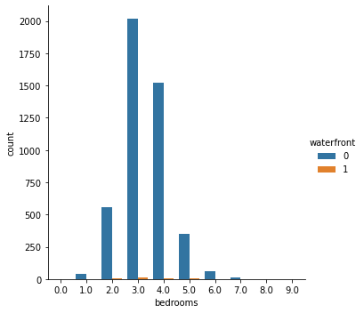

```python
sns.catplot(x = "bedrooms", hue = "waterfront", kind = "count", data = df)
```

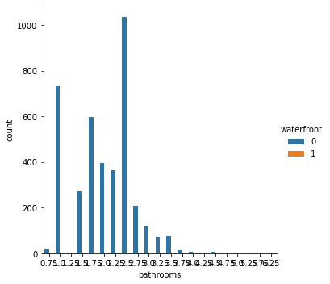

```python
sns.catplot(x = "bathrooms", hue = "waterfront", kind = "count", data = df1)
```

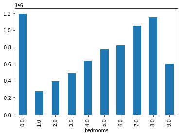

```python
df.groupby('bedrooms').price.mean().plot.bar()
```

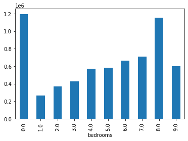

```python
df.groupby('bedrooms').price.median().plot.bar()
```

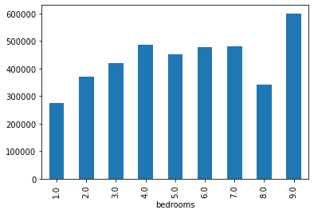

```python
df1.groupby('bedrooms').price.mean().plot.bar()
```

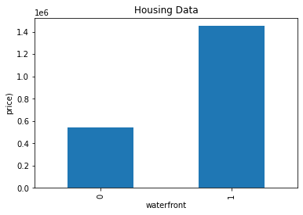

```python
df.groupby('waterfront').price.mean().plot.bar()
plt.xlabel('waterfront')
plt.ylabel('price)')
plt.title('Housing Data')
```

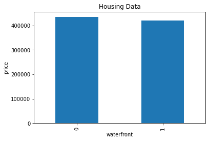

```python
df1.groupby('waterfront').price.mean().plot.bar()
# Among houses within $500,000, waterfront decreases price
plt.xlabel('waterfront')
plt.ylabel('price')
plt.title('Housing Data')
```

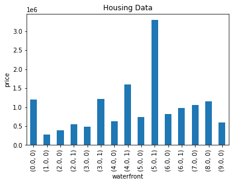

```python
# Among all houses, those with waerfront have higher average prices
df.groupby(['bedrooms', 'waterfront']).price.mean().plot.bar()
plt.xlabel('waterfront')
plt.ylabel('price')
plt.title('Housing Data')
```

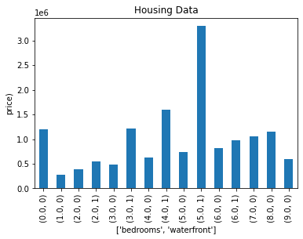

```python
df.groupby(['bedrooms', 'waterfront']).mean().agg('price').plot.bar()
plt.xlabel(['bedrooms', 'waterfront'])
plt.ylabel('price)')
plt.title('Housing Data')
```

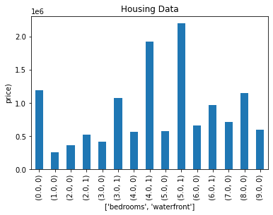

```python
df.groupby(['bedrooms', 'waterfront']).median().agg('price').plot.bar()
plt.xlabel(['bedrooms', 'waterfront'])
plt.ylabel('price)')
plt.title('Housing Data')
```

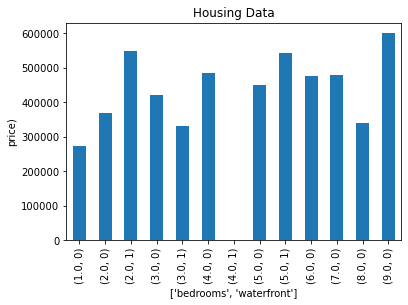

```python
df1.groupby(['bedrooms', 'waterfront']).mean().agg('price').plot.bar()
plt.xlabel(['bedrooms', 'waterfront'])
plt.ylabel('price)')
plt.title('Housing Data')
```

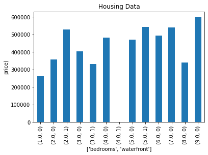

```python
df1.groupby(['bedrooms', 'waterfront']).median().agg('price').plot.bar()
plt.xlabel(['bedrooms', 'waterfront'])
plt.ylabel('price)')
plt.title('Housing Data')
```

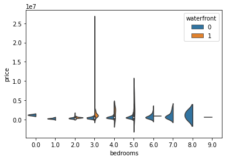

```python
sns.violinplot(x ="bedrooms", y ="price", hue ="waterfront",
               data = df, split = True)
```

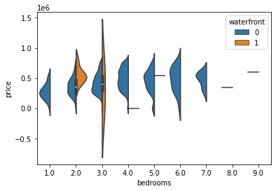

```python
sns.violinplot(x ="bedrooms", y ="price", hue ="waterfront",
               data = df1, split = True)
```

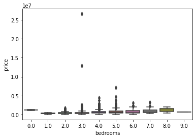

```python
sns.boxplot(x = 'bedrooms',y='price',data=df)
```

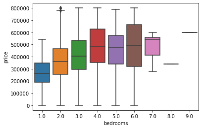

```python
sns.boxplot(x = 'bedrooms', y = 'price', data = df1)
```

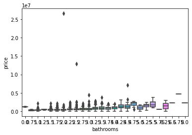

```python
sns.boxplot(x = 'bathrooms', y = 'price', data = df)
```

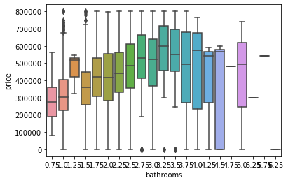

```python
sns.boxplot(x = 'bathrooms', y = 'price', data = df1)
```

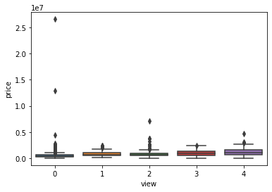

```python
sns.boxplot(x = 'view', y = 'price', data = df)
```

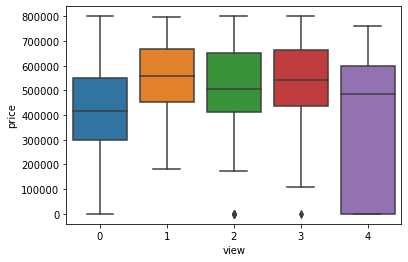

```python
sns.boxplot(x = 'view', y = 'price', data = df1)
```

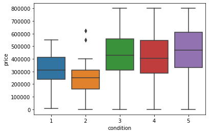

```python
sns.boxplot(x = 'condition', y = 'price', data = df1)
```

Condition 2 has the least priced houses or does the condition to decreases the price of the houses?